# Разработка модели машиного обучения с целью увеличения покупательской активности постоянных клиентов.

### Выберем группу покупателей для предложения увеличения её покупательской активности

Далее отберем клиентов, которые с высокой вероятностью (>=0.7) снизят покупательскую способность, но при этом приносят высокую прибыль (>=4). Это и есть целевая аудитория, на которую можно воздействовать.

```python
money_pred_prob['Категория'] = 'Не целевая'
terms = (money_pred_prob['Прибыль']>=4)&(money_pred_prob['Вероятность_снижения']>=0.7)
money_pred_prob.loc[terms, 'Категория'] = 'Целевая'
money_pred_prob.head()
```

|  | id | Прибыль | Вероятность_снижения | Категория |
| --- | --- | --- | --- | --- |
| 0 | 215348 | 0.98 | 0.194104 | Не целевая |
| 1 | 215349 | 4.16 | 0.862300 | Целевая |
| 2 | 215350 | 3.13 | 0.861283 | Не целевая |
| 3 | 215351 | 4.87 | 0.966362 | Целевая |
| 4 | 215352 | 4.21 | 0.651911 | Не целевая |

```python
money_pred_prob['Категория'].value_counts()
```

```
Не целевая    1200
Целевая        100
Name: Категория, dtype: int64
```

**Получившаяся целевая категория** - 100 покупателей с прибыльностью более 4 и вероятностью снизить покупательскую способность более 0.7.

Далее по этим покупателям проведем анализ по товарным категориям: какая из них больше приносит деньги, какая менее прибыльная и по типу сервиса, какой сервис больше приносит доход.

```python
target_category = money_pred_prob.query('Категория=="Целевая"')
target_category.head()
```

|  | id | Прибыль | Вероятность_снижения | Категория |
| --- | --- | --- | --- | --- |
| 1 | 215349 | 4.16 | 0.862300 | Целевая |
| 3 | 215351 | 4.87 | 0.966362 | Целевая |
| 8 | 215356 | 4.93 | 0.803378 | Целевая |
| 13 | 215361 | 4.03 | 0.873089 | Целевая |
| 26 | 215374 | 4.08 | 0.956532 | Целевая |

```python
checking_target_category = market.merge(target_category, how='left', on=['id'])
checking_target_category.head(3)
```

|  | id | Покупательская_активность | Тип_сервиса | Разрешить_сообщать | Маркет_актив_6_мес | Маркет_актив_тек_мес | Длительность | Акционные_покупки | Популярная_категория | Средний_просмотр_категорий_за_визит | ... | Ошибка_сервиса | Страниц_за_визит | Выручка_текущий_месяц | Минут_текущий_месяц | Выручка_предыдущий_месяц | Выручка_препредыдущий_месяц | Минут_предыдущий_месяц | Прибыль | Вероятность_снижения | Категория |
| --- | --- | --- | --- | --- | --- | --- | --- | --- | --- | --- | --- | --- | --- | --- | --- | --- | --- | --- | --- | --- | --- |
| 0 | 215349 | 0 | премиум | да | 4.4 | 4 | 819 | 0.75 | Товары для детей | 4 | ... | 2 | 5 | 4971.6 | 10.0 | 5216.0 | 4472.0 | 12.0 | 4.16 | 0.862300 | Целевая |
| 1 | 215350 | 0 | стандарт | нет | 4.9 | 3 | 539 | 0.14 | Домашний текстиль | 5 | ... | 1 | 5 | 5058.4 | 13.0 | 5457.5 | 4826.0 | 8.0 | NaN | NaN | NaN |
| 2 | 215351 | 0 | стандарт | да | 3.2 | 5 | 896 | 0.99 | Товары для детей | 5 | ... | 6 | 4 | 6610.4 | 13.0 | 6158.0 | 4793.0 | 11.0 | 4.87 | 0.966362 | Целевая |

3 rows × 21 columns

```python
checking_target_category = checking_target_category.dropna()
```

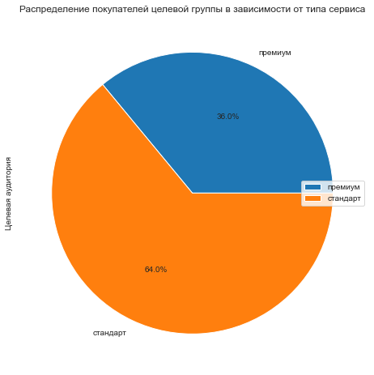

```python
plt.rcParams.update({'font.size': 10})
Serv = checking_target_category.pivot_table(
    index='Тип_сервиса',
    values='id',
    aggfunc='count').sort_values('id').plot(kind='pie', y='id',
                        ylabel='Целевая аудитория',
                        title = 'Распределение покупателей целевой группы в зависимости от типа сервиса',
                        autopct='%1.1f%%',
                        figsize=(8,8))
plt.legend(loc=5)
plt.show()
```

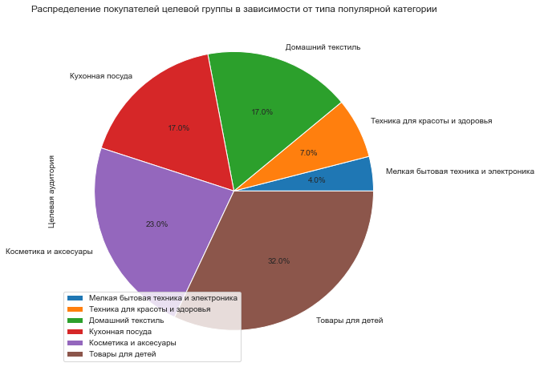

```python
plt.rcParams.update({'font.size': 10})
Serv = checking_target_category.pivot_table(
    index='Популярная_категория',
    values='id',
    aggfunc='count').sort_values('id').plot(kind='pie', y='id',
                        ylabel='Целевая аудитория',
                        title = 'Распределение покупателей целевой группы в зависимости от типа популярной категории',
                        autopct='%1.1f%%',
                        figsize=(8,8))
plt.legend(loc=3)
plt.show()
```

### Выводы по сегментации покупателей

- Получившаяся целевая категория - 100 покупателей с прибыльностью более 4 и вероятностью снизить покупательскую способность более 0.7.
- По результату исследования можно дать предложение о проведении маркетинговой компании, направленной на увеличение продаж товаров для детей, товаров домашнего текстиля и посуды. Также стоит обратить внимание на покупателей, выбравших сервис "стандарт". Возможно, именно для типа сервиса "стандарт" стоит чаще проводить маркетинговые компании.

## Общий вывод

**Задача проекта** - разработка решения, которое позволит персонализировать предложения постоянным клиентам, чтобы увеличить их покупательскую активность.

**Выводы по исходным данным и предобработке данных:**

- По первичной информации замечены неправильные типы данных, ошибки в данных, а также нестандартное оформление названия столбцов.
- Данные в таблицах соответствуют описанию.

По итогам предобработке данных:

- привели названия столбцов к стандартам оформления данных;
- проверили пропуски в данных;
- проверили данные на явные и неявные пропуски и избавлись от них;
- преобразовали данные к правильному типу. Данные с плавающей запятой типа `object` были заменены на данные с плавающей точкой типа `float64`.

**Для поиска лучшей модели были выполнены следующие шаги:**

- Создали списки с названиями признаков
- Создали пайплайн для подготовки признаков из списка `ohe_columns`: заполнение пропусков и OHE-кодирование SimpleImputer + OHE
- Создали пайплайн для подготовки признаков из списка ord_columns: заполнение пропусков и Ordinal-кодирование SimpleImputer + OE
- Создали общий пайплайн для подготовки данных
- Создали итоговый пайплайн: подготовка данных и модель
- Создали словари для моделей
- Нашли лучшую модель и ее параметры с помощью `RandomizedSearchCV()`

**Лучшая модель:** SVC с гиперпараметрами C=0.1, kernel='linear', degree=4, gamma=0.1, random_state=42

**Выводы по сегментации покупателей:**

- Была выбрана группа: "Клиенты с высокой вероятностью снижения покупательской активности и наиболее высокой прибыльностью"
- По выбранному сегменту проведен анализ по товарным категориям и типу сервису, по которому сформулировано предложение о проведении маркетинговой компании, направленной на увеличение продаж товаров для детей, товаров домашнего текстиля и посуды. Также стоит обратить внимание на покупателей, выбравших сервис "стандарт". Возможно, именно для типа сервиса "стандарт" стоит чаще проводить маркетинговые компании.